### Part II

#### Solution

Tuesday, November 18, 2014

**5.** Consider the first five rows of the data set `problem5.txt`:

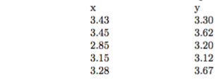

There are twenty-five ($25$) data lines total. Justify your answers (when you use a computer package to do calculations, explain what you did) for full credit. You should specify any assumptions you make. When appropriate, use the assumption of constant variance between groups.

1. Suppose that $x$ and $y$ represent grade point averages for a random sample of $25$ students in morning sections (‘x’) and $25$ in afternoon sections (‘y’) of a particular course.

a.i) Is this enough evidence to show that the grade point averages of students in afternoon sections is larger than the grade point averages of students in morning sections? (Use $\alpha = 0.05$).  
**Solution**

```r
raw.text <- "
x  y
3.43    3.3
3.45    3.62
2.85    3.2
3.15    3.12
3.28    3.67
2.8 3.15
3.46    3.63
2.24    2.39
3.75    3.97
3.34    3.16
4   3.69
2.79    3
2.81    2.69
2.73    2.7
3.39    3.75
4   4
3.24    3.68
3.27    3.1
2.89    3
4   4
3.51    3.37
2.89    3.08
3.56    3.29
3.87    4
3.43    3.91
"

gpa.df <- read.table(header=TRUE, text=raw.text)
gpa.t <- t.test(x=gpa.df$x, y=gpa.df$y, alternative="less", var.equal=TRUE)
```

“We assume that 25 in each group is large enough for the Central Limit Theorem to have sample means be normal and that the variances in the two groups are the same.”  
$H_0: \mu_x = \mu_y$  
$H_a: \mu_x < \mu_y$  
T.S.: $t^* = -.7301$  
*p*-value = $0.2344$  
There is not evidence to show that the GPAs of students in the afternoon sections is larger than the GPAs of students in the morning sections.  
a.ii) Give a 95% confidence interval for the difference between the grade point averages for the individuals in afternoon sections vs. morning sections.  
**Solution**

```r
# To get proper CI, change `alternative` parameter to "two.sided"
t.test(x=gpa.df$x, y=gpa.df$y, alternative="two.sided", var.equal=TRUE)$conf.int
```

```
## [1] -0.3513626  0.1641626
## attr(,"conf.level")
## [1] 0.95
```

“We are 95% confident that the difference between the mean GPAs of morning students and afternoon students is between -0.3514 and 0.1642.”

2. Suppose that the $x$ and $y$ represent grade point averages for a random sample of $50$ students at CSUEB, but it happens that they were recorded in 2 columns.

b.i) Is this enough evidence to show that the mean GPA at CSUEB is above $3.1$? (Use $\alpha = 0.05$).  
**Solution**  
One-sample *t* test  
$H_0: \mu \leq 3.1$  
$H_a: \mu > 3.1$  
T.S. $t^* = \frac{\overline{GPA} - 3.1}{s/\sqrt{50}}$

```r
t.test(x=c(gpa.df$x, gpa.df$y), alternative="greater", mu=3.1)
```

```
##
##  One Sample t-test
##
## data:  c(gpa.df$x, gpa.df$y)
## t = 3.6367, df = 49, p-value = 0.0003312
## alternative hypothesis: true mean is greater than 3.1
## 95 percent confidence interval:
##  3.225047      Inf
## sample estimates:
## mean of x
##     3.332
```

“We assume that 50 is large enough for the Central Limit Theorem to have the sample mean be normally distributed. $t^* = 3.64$ and *p*-value $= 0.0003$. This is enough evidence to show that the GPAs of students is larger than 3.1.”

b.ii) Give a 95% confidence interval for the mean GPA at CSUEB.  
**Solution**

```r
t.test(x=c(gpa.df$x, gpa.df$y))
```

```
##
##  One Sample t-test
##
## data:  c(gpa.df$x, gpa.df$y)
## t = 52.2309, df = 49, p-value < 2.2e-16
## alternative hypothesis: true mean is not equal to 0
## 95 percent confidence interval:
##  3.203802 3.460198
## sample estimates:
## mean of x
##     3.332
```

“We are 95% confidenct that the mean GPA at CSUEB is between 3.2038 and 3.4602.”

3. Suppose that the numbers represent grade point averages for a random sample of $25$ students at CSUEB, where $x$ represents the grade point averages in lower division courses and $y$ represents the grade point averages in upper division courses.

c.i) Is this enough evidence to show upper division and lower division grade point averages differ? (Use $\alpha = 0.05$).  
**Solution**  
Each row of data refers to one student. This is a paired *t* test.  
$H_0: \mu_x = \mu_y$  
$H_a: \mu_x \neq \mu_y$  
T.S.:

```r
t.test(x=gpa.df$x, y=gpa.df$y, paired=TRUE)
```

```
##
##  Paired t-test
##
## data:  gpa.df$x and gpa.df$y
## t = -2.0486, df = 24, p-value = 0.05159
## alternative hypothesis: true difference in means is not equal to 0
## 95 percent confidence interval:
##  -0.1879006674  0.0007006674
## sample estimates:
## mean of the differences
##                 -0.0936
```

“We assume that 25 differences is large enough for the Central Limit Theorem to have the sample mean difference be normal. $t^*=-2.0486$, *p*-value $=0.05159$. This is not enough evidence to show that upper division and lower division GPAs differ.”

c.ii) Give a 95% confidence interval for the difference between upper division and lower division grade point averages.  
**Solution**  
“We are 95% confident that the mean difference between lower division and upper division GPAs at CSUEB is between -0.1879 and 0.0007.”

4. Using only the numbers from column $y$, is this enough evidence to show that upper division grade point averages differ from $3.1$? (Use $\alpha = 0.05$). Use an appropriate nonparametric test.  
   **Solution**  
   $H_0: \mu_y = 3.1$  
   $H_a: \mu_y \neq 3.1$  
   T.S.:

```r
library(MASS)
wilcox.test(x=gpa.df$y, mu=3.1)
```

```
##
##  Wilcoxon signed rank test with continuity correction
##
## data:  gpa.df$y
## V = 244.5, p-value = 0.007211
## alternative hypothesis: true location is not equal to 3.1
```

“We can use either the signed-rank test or the sign test. If the signed-rank test is used, we assume that the population is symmetric (hence, the median and the mean are the same). According to SAS, the *p*-value for the signed-rank test is 0.0043. (Note: MINITAB gives a p-value of 0.007.) We conclude that the median GPA is different from 3.1.”